# Introduction to $I-V$ Curves

Xuan Ma, Wei-Heng Huang

2021-04-14

An $I-V$ curve indicates the relationship between current and voltage for a solar cell or module. Thus for a single $I-V$ curve, the dataset usually consists of several data points of voltage $V$ and the associated current $I$. As is shown in Figure 1, a standard $I-V$ curve has the shape of a concave curve with nearly no change of current at small voltage, and a sharp decrease of current at a certain voltage point.

Solar cell parameters in $I-V$ curves are important in evaluating the performance and degradation of PV modules. These performance parameters include the maximum power point $P_{mp}$, short-circuit current $I_{sc}$, open-circuit voltage $V_{oc}$, shunt resistance $R_{sh}$, series resistance $R_s$, and fill factor $FF$. The first five of these parameters are illustrated in Figure 1. $I_{sc}$ is defined as the current at zero voltage (the y-intercept of the $I-V$ curve), while $V_{oc}$ is the voltage at zero current (the x-intercept). $R_{sh}$ is equivalent to the negative of inverse slope of the $I-V$ curve near $I_{sc}$. $R_s$ is equivalent to the negative of inverse slope of the $I-V$ curve near $V_{oc}$. $P_{mp}$ is the maximum product of current and voltage on the $I-V$ curve. $FF$ is defined as the ratio of the maximum power from the solar cell to the product of $V_{oc}$ and $I_{sc}$, it measures the “squareness” of the solar cell. $FF$ is not shown in Figure 1 directly, but can be calculated with the equation

$$\begin{equation}
FF= \frac{P_{max}}{I_{sc}*V_{oc}}
\label{ff}
\end{equation}$$

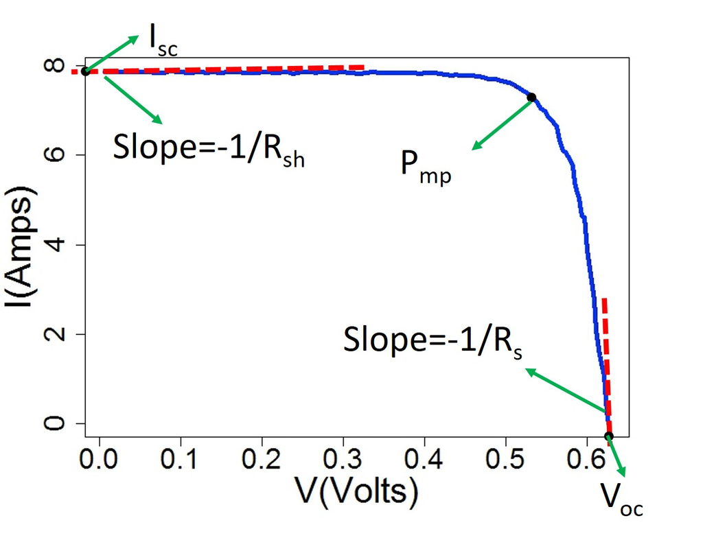

Figure 1: A standard $I-V$ curve and $I-V$ features. $I-V$ curve shows the relationship between current($I$) and voltage ($V$). $I-V$ features are maximum power point ($P_{mp}$), short-circuit current ($I_{sc}$), open-circuit voltage ($V_{oc}$), shunt resistance ($R_{sh}$), series resistance ($R_s$), and fill factor ($FF$)

We define the in the $I-V$ curves as how many typical $I-V$ curve shapes appear in the current-voltage relationship. The standard $I-V$ curve shown in Figure 1 is said to have only one step. There are cases (e.g. when it is cloudy) where several steps are present in a single $I-V$ curve due to activation of the bypass diodes. An example of $I-V$ curves with steps is demonstrated in Figure 2. This $I-V$ curve looks like a combination of three standard $I-V$ curves. This pattern of $I-V$ curves is an indication of mismatch between different areas of the array of module under test. This may be caused by a partial shading of the PV array or damage of PV cells, causing bypass diodes to activate. If a step is caused by partially shaded array, then the step would be transient and disappear from future $I-V$ curves. However, if the PV cell is damaged, then the step would be permanent.

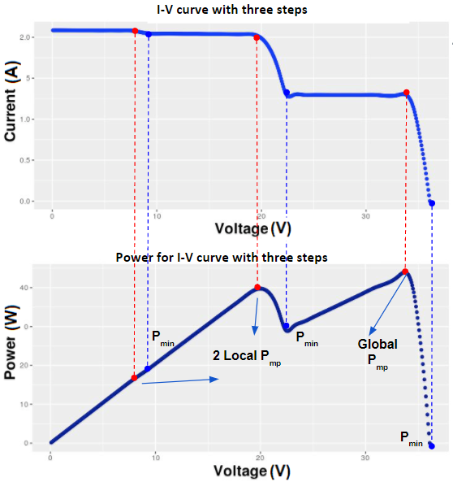

Figure 2: An example of $I-V$ curve that has three steps. The $I-V$ curve is a combination of three standard $I-V$ curves. There are three local maximum power point for each standard $I-V$ curves. Out of these three, one is the global maximum power point.

## Load data and run code to extract $I-V$ features

```r
library(ddiv)
## Use the example IV curve data that has two steps
## Load the IV curve data set
data(IV_step2)
IV2 <- data.frame(IV_step2)
#?IV_step2

## Calculate number of steps in IV curve
IVsteps(IV2$I,IV2$V,plot.option=FALSE)
```

```
## $step
## [1] 2
##
## $xsep
##       V1
## 1 10.594
```

```r
## Extract two sets of IV features for each sub IV curves
IVExtractResult(IV2,plot.option=FALSE)
```

```
##   step            Isc                Rsh              Voc              Rs
## 1    2 V1#1.732#1.917 V1#2732.708#46.831 V1#68.612#37.133 V1#34.319#1.082
##                Pmp            Imp              Vmp             FF    Cutoff
## 1 V1#17.841#55.137 V1#1.692#1.646 V1#10.544#33.489 V1#15.01#77.46 V1#10.594
```